# Problema2 - Parte2

Arthur Sena

05/01/2015

```r
library(ggplot2, quietly = T, warn.conflicts = F)
library(dplyr, quietly = T, warn.conflicts = F)
```

# Descrição dos dados:

```r
    deputados <- read.csv("AnoAtual.csv")
```

Os dados usados nesse experimento foram obtidos do site da Câmara dos Deputados e seu conteúdo pode ser acessado clicando [aqui](http://www2.camara.leg.br/transparencia/cota-para-exercicio-da-atividade-parlamentar/dados-abertos-cota-parlamentar). Tais dados são relativos aos gastos parlamentares registrados na Câmara dos Deputados. Abaixo, pode ser visto uma pequena amostra do seu conteúdo:

```r
    amostra <- select(deputados, txNomeParlamentar, ideCadastro, sgPartido,  vlrLiquido)
    head(amostra,n = 10)
```

```
##         txNomeParlamentar ideCadastro sgPartido vlrLiquido
## 1      LUIS CARLOS HEINZE       73483        PP    3700.00
## 2          GERALDO THADEU       74151       PSD    3504.55
## 3   CARLOS EDUARDO CADOCA       74474     PCdoB    1450.90
## 4              JOÃO DERLY      178965     PCdoB     988.10
## 5            MILTON MONTI       74787        PR     952.50
## 6        LAERCIO OLIVEIRA      151208        SD     853.60
## 7        NILMÁRIO MIRANDA       74751        PT     694.80
## 8  JOÃO FERNANDO COUTINHO      178917       PSB     603.72
## 9          GORETE PEREIRA      129618        PR     599.00
## 10     JOSÉ AIRTON CIRILO      141464        PT     599.00
```

Todas as variáveis/colunas e suas, respectivas, descrições podem ser visualizadas no [link](http://www2.camara.leg.br/transparencia/cota-para-exercicio-da-atividade-parlamentar/explicacoes-sobre-o-formato-dos-arquivos-xml).

# Analisando os dados

Com esses dados em mãos, nós podemos fazer algumas análises interessantes sobre eles. Por exemplo, vamos calcular a média da variável “vlrLiquido” para aquelas despesas relativa à serviços portais.

```r
  servicosPostais_gastos <- deputados %>% select(txNomeParlamentar,vlrLiquido,txtDescricao,sgUF,sgPartido) %>% filter  (txtDescricao == "SERVIÇOS POSTAIS")
  mean(servicosPostais_gastos$vlrLiquido)
```

```
## [1] 118.2888
```

A fim de fazer uma análise mais detalhada, abaixo se encontra a função de distribuição de probabilidade, no qual representas chances de um determinado valor ser assumido pela variavel.

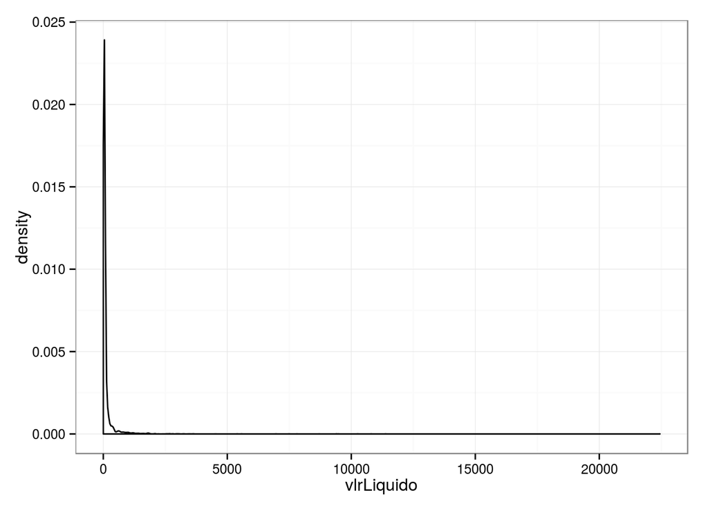

```r
      ggplot( servicosPostais_gastos, aes(vlrLiquido)) +
  geom_density() +
  theme_bw()
```

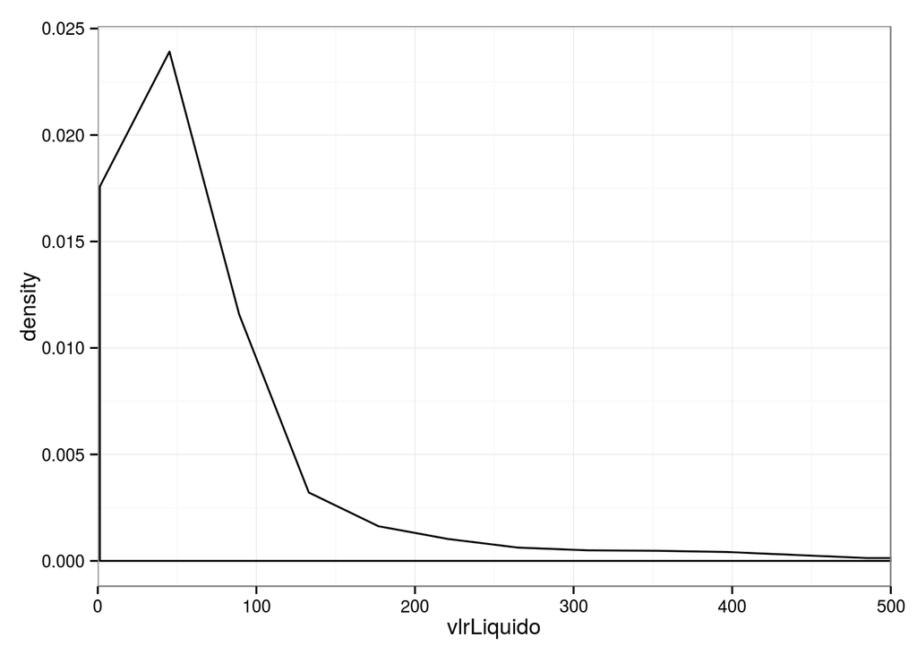

```r
  ggplot( servicosPostais_gastos, aes(vlrLiquido)) +
   geom_density() +coord_cartesian(xlim=c(0, 500))+
   theme_bw()
```

Visualizando distribuição de probabilidade do gráfico acima, podemos observar que a variável apresenta uma maior chance de obter valores abaixo de R$500,00 reais. A partir dos gráficos acima observados, podemos demontrar alguns conceitos interessantes de estatistica, como por exemplo: O teorema do limite central. Tal teorema afirma que “Qualquer que seja a distribuição da variável de interesse para grande amostras, a distribuição das médias amostrais serão aproximadamente normalmente distribuídas”. A fim de um melhor entendimento sobre o teorema, podemos demontrá-lo utilizando os gastos de Serviços Postais dos deputados.

Primeiramente, vamos reunir 10 amostras de tamanho 100 da nossa população e calcular, para cada amostra, sua média. Feito isso, vamos visualizar a distribuição de probabilidade para as médias das nossas amostras.

# 10 amostras coletadas

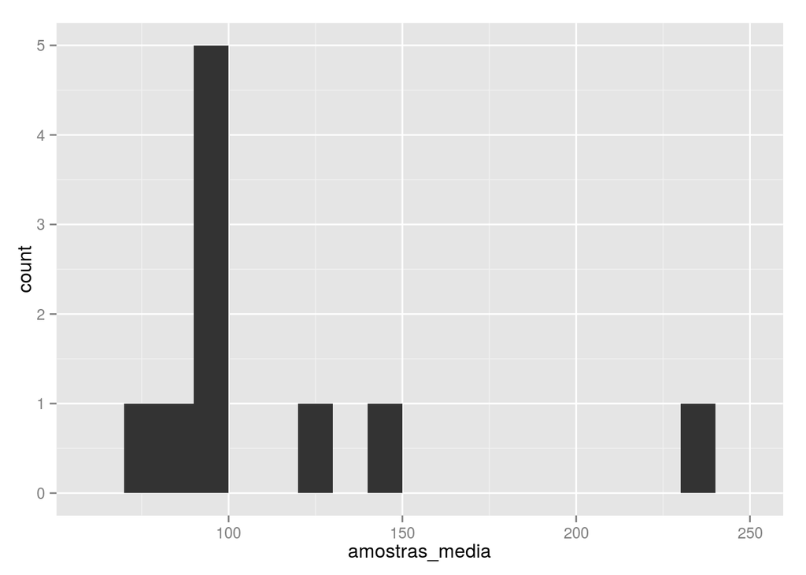

```r
dist_original <- servicosPostais_gastos$vlrLiquido
amostra_tamanho <- 100
num_amostras <- 10

amostras_media <- c()
for(i in seq(1, num_amostras)){
  uma_amostra <- sample(dist_original, amostra_tamanho)
  amostras_media[i] <- mean(uma_amostra)
}

ggplot(data.frame(amostras_media), aes(amostras_media)) + geom_histogram(binwidth = 10)
```

# 100 amostras coletadas

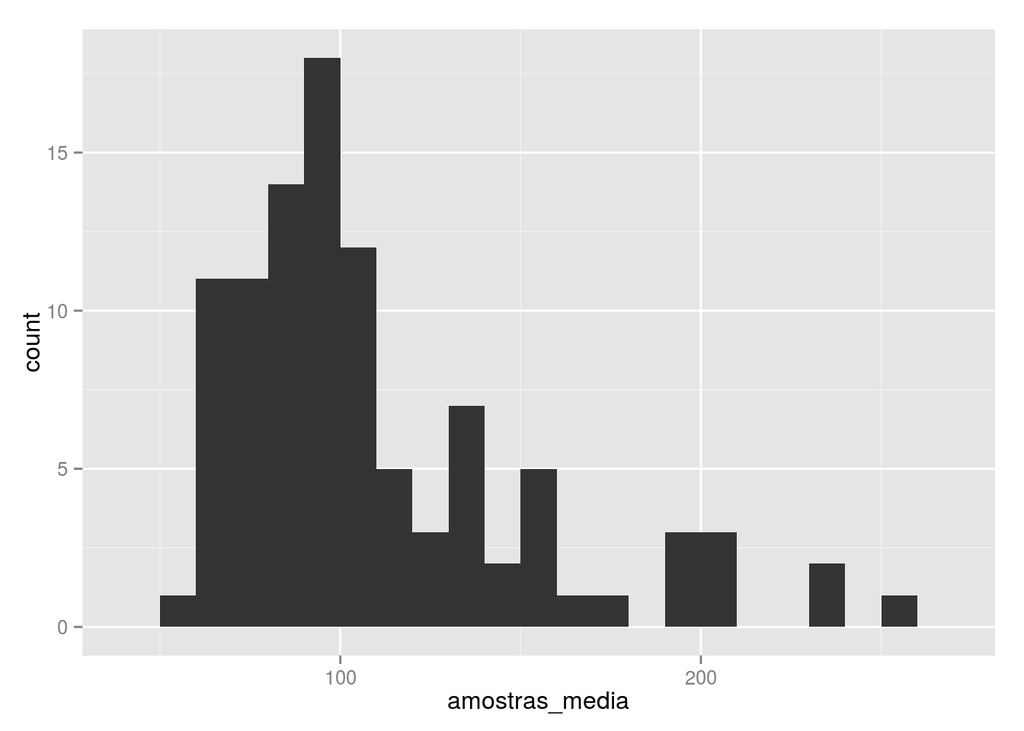

```r
dist_original <- servicosPostais_gastos$vlrLiquido
amostra_tamanho <- 100
num_amostras <- 100

amostras_media <- c()
for(i in seq(1, num_amostras)){
  uma_amostra <- sample(dist_original, amostra_tamanho)
  amostras_media[i] <- mean(uma_amostra)
}

ggplot(data.frame(amostras_media), aes(amostras_media)) + geom_histogram(binwidth = 10)
```

# 1000 amostras coletadas

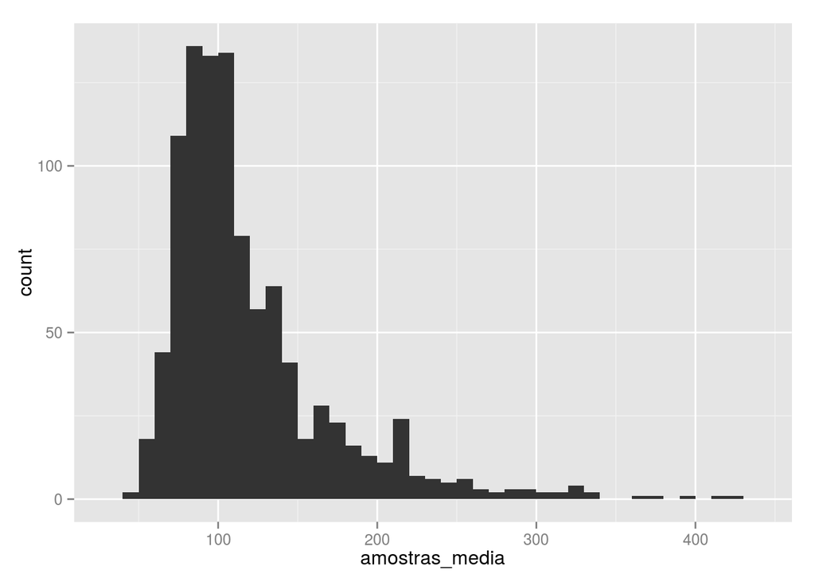

```r
dist_original <- servicosPostais_gastos$vlrLiquido
amostra_tamanho <- 100
num_amostras <- 1000

amostras_media <- c()
for(i in seq(1, num_amostras)){
  uma_amostra <- sample(dist_original, amostra_tamanho)
  amostras_media[i] <- mean(uma_amostra)
}

ggplot(data.frame(amostras_media), aes(amostras_media)) + geom_histogram(binwidth = 10)
```

# 10000 amostras coletadas

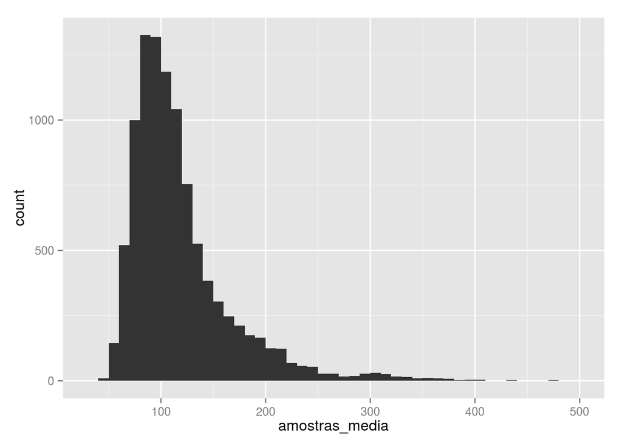

```r
dist_original <- servicosPostais_gastos$vlrLiquido
amostra_tamanho <- 100
num_amostras <- 10000

amostras_media <- c()
for(i in seq(1, num_amostras)){
  uma_amostra <- sample(dist_original, amostra_tamanho)
  amostras_media[i] <- mean(uma_amostra)
}

ggplot(data.frame(amostras_media), aes(amostras_media)) + geom_histogram(binwidth = 10)
```

# Intervalos de Confiança

Outro conceito interessante, e que vale ser mencionado nessa análise, é o conceito de Intervalos de Confiança, no qual se destinam a mensurar um intervalo, relativo a média de cada amostra, onde a média da população se encontra. Ou seja, se eu tenho uma amostra com média X, então eu posso determinar um intervalo relativo à X, no qual a média da população pode estar inserida. Esse intervalo será determinado pode ser definido como: **(X - Erro, X + Erro)**.Onde, o erro será definido pela fórmula:  
$dp = desvioPadrao(amostra)$ $Erro = 1.96*dp/raizQuadrada(amostraTamanho)$

Assim sendo, podemos definir um intervalo de confiança para cada amostra coletada anteriormente e visualizar tais intervalos em um gráfico.

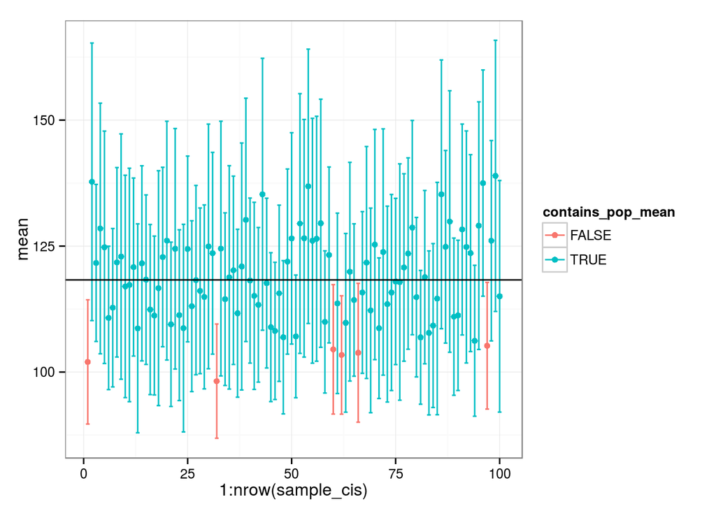

```r
    dist_original <-(servicosPostais_gastos$vlrLiquido)
    amostra_tamanho <- 2500
    num_amostras <- 100
    pop_mean <- mean(dist_original)

    calcula_intervalo <- function(amostra,tamanhoAmostra){
      temp <- as.data.frame(amostra)
      se <- sd(temp[,1])/sqrt(tamanhoAmostra)
      inferior <- mean(amostra) - (1.96*se)
      superior <- mean(amostra) + (1.96*se)
      list("mean"=mean(amostra) , "lower"=inferior,"upper"=superior)
      }

    sample_cis <- data.frame(upper = c(), mean = c(), lower = c())
    for(i in seq(1, num_amostras)){
          a_sample <- sample(dist_original, amostra_tamanho)
          interval <-  calcula_intervalo(a_sample,  amostra_tamanho)
          sample_cis <- rbind(sample_cis, data.frame(mean = interval["mean"], lower = interval["lower"],upper = interval["upper"]))
  }
    sample_cis <- sample_cis %>% mutate(contains_pop_mean = (upper >= pop_mean & lower <= pop_mean))

    ggplot(sample_cis, aes(x = 1:nrow(sample_cis), y = mean, colour = contains_pop_mean)) +
     geom_point() +
      geom_errorbar(aes(ymin = lower, ymax = upper)) +
#          geom_hline(aes(yintercept=mean(mean(dist_original)))) +
  geom_hline(aes(yintercept=pop_mean)) +
             theme_bw()
```

Cada ponto azul e vermelho acima representa o valor da média da amostra, onde as barras acima e abaixo dos pontos representa a extensão dos seus, respectivos, intervalos de confiança. Os pontos e barras vermelhos são aqueles no qual a média da população não se encontra inserida nos seus intervalos. A barra preta desenhada horizontalmente representa a média da população.

Eu calculei os intervalos com um nível de confiança de 95%, ou seja, a probabilidade de que , com várias repetições, os intervalos conterão o verdadeiro valor do parâmetro. O que é facilmente observado no gráfico, pois apenas seis intervalos não contiveram a média da população. É importante notar que as margens de erros dos intervalos são inversamente proporcionais ao tamanho das amostras, ou seja, quanto maior o tamanho menor a margem de erro.